# Introduction to Image Recognition with the MNIST Dataset

Computational Methods, DPIR, University of Oxford

Marie-Lou Sohnius

Hilary Term 2024

# Understanding Image Data in Computational Analysis

In the realm of computational methods, particularly within the social sciences, the utilization of images as data presents a fascinating intersection of technology and human behavior analysis. At its core, the concept of image recognition revolves around converting visual information into a format that can be interpreted and analyzed by computational algorithms.

Think, for example, of a parliamentary speeches, a commonly used data source. Usually, we use transcripts of speeches to analyse behavior of politicians and parties. But there is additional information that we cannot capture. Emotionality, gestures, who looks at their phone and who listens to a speech? And when? These kinds of questions would be answerable with image recognition methods.

Images, in their raw form, are essentially arrays of pixel values. These pixels, when viewed collectively, form the images that we perceive. However, for a computer, these are numerical values in a grid-like structure. Each pixel in an image is represented by a numerical value, which typically indicates its color and intensity. In grayscale images, like those we will be dealing with in our lab, these values range from 0 (black) to 255 (white).

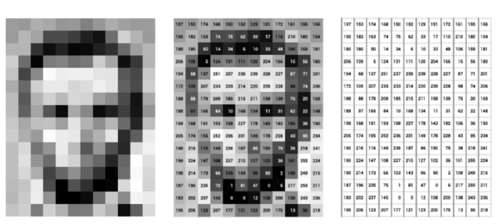

Image of a Person’s Face as a matrix of Pixel values.

The transformation of these pixel values into data that can be analyzed is a critical step in image recognition. This process involves flattening the image - turning the two-dimensional array of pixels into a one-dimensional array that can be fed into a classification algorithm. In doing so, each image becomes a series of numerical values, each representing a specific feature of the image. For today, we will work with data where this processing step has already been done for us.

In this session, we will train a neural network model to classify images of clothing, like sneakers and shirts. It’s fine if you don’t understand all the details, this is a fast-paced overview of a complete `Keras` program with the details explained as we go.

```r
# Let's get started!

rm(list=ls()) # Clear working environment

## Global options
knitr::opts_chunk$set(cache = TRUE, warning = FALSE, message = FALSE)

# The following chunk checks and installs all packages needed for running the
# code.

# install.packages("pacman") # Uncomment if you don't have pacman installed yet!
library(pacman)

## Load (and install) packages needed for the analyses
pacman::p_load(tidyverse,  # Cleaning data, plotting pretty plots ;)
               keras,      # Build and train deep learning models
               viridis,    # Colourblind palettes for plots
               rmdformats) # Style the RMD HTML output
```

# Fashion MNIST

## Import the Fashion MNIST dataset

Today, we’re working with the Fashion MNIST dataset, which contains 70,000 grayscale images divided into 10 categories of clothing items[^1]. Each image is presented in a resolution of 28 by 28 pixels. Designed as an update to the classic MNIST dataset of handwritten digits, Fashion MNIST offers a bit more complexity, serving as a practical tool for exploring machine learning in the area of computer vision.

[figure not shown]

Figure 1. Fashion-MNIST samples (by Zalando, MIT License).

The approach is straightforward: we use 60,000 images for training our model and the remaining 10,000 for testing its ability to classify unseen clothing items. The preprocessing of these images has been handled in advance, allowing us to focus directly on model development and evaluation.

Access to the Fashion MNIST dataset is facilitated through the `Keras` package, simplifying the process of starting with machine learning projects. This dataset provides a balanced challenge for applying and understanding neural networks in visual data classification.

```r
# Load in the dataset
fashion_mnist <- dataset_fashion_mnist()

# Let's check the dimensions of this datasets
rapply(fashion_mnist, dim)
```

```
## train.x1 train.x2 train.x3  train.y  test.x1  test.x2  test.x3   test.y
##    60000       28       28    60000    10000       28       28    10000
```

```r
# What is in each data frame? Let's check out the train item.
# fashion_mnist$train

# Subset the data into training and test data
c(train_images, train_labels) %<-% fashion_mnist$train
c(test_images, test_labels) %<-% fashion_mnist$test
```

Now we have four arrays: The train_images and train_labels arrays are the training set — the data the model uses to learn. The model is tested against the test set, i.e. the test_images, and test_labels arrays.

| Digit | Class |
| --- | --- |
| 0 | T-shirt/top |
| 1 | Trouser |
| 2 | Pullover |
| 3 | Dress |
| 4 | Coat |
| 5 | Sandal |
| 6 | Shirt |
| 7 | Sneaker |
| 8 | Bag |
| 9 | Ankle boot |

Each image is mapped to a single label. Since the class names are not included with the dataset, we’ll store them in a vector to use later when plotting the images.

```r
class_names <-  c('T-shirt/top',
                  'Trouser',
                  'Pullover',
                  'Dress',
                  'Coat',
                  'Sandal',
                  'Shirt',
                  'Sneaker',
                  'Bag',
                  'Ankle boot')
```

## Explore the data

Let’s explore the format of the dataset before training the model. The following shows there are 60,000 images in the training set, with each image represented as 28 x 28 pixels:

```r
dim(train_images)
```

```
## [1] 60000    28    28
```

As there are 60,000 images, there are also 60,000 corresponding labels in the training set:

```r
dim(train_labels)
```

```
## [1] 60000
```

Each label is an integer between 0 and 9:

```r
# Check out the first twenty labels
train_labels[1:20]
```

```
##  [1] 9 0 0 3 0 2 7 2 5 5 0 9 5 5 7 9 1 0 6 4
```

Let’s check out the distribution of items (clothes) in our dataset. How many images do we have of each?

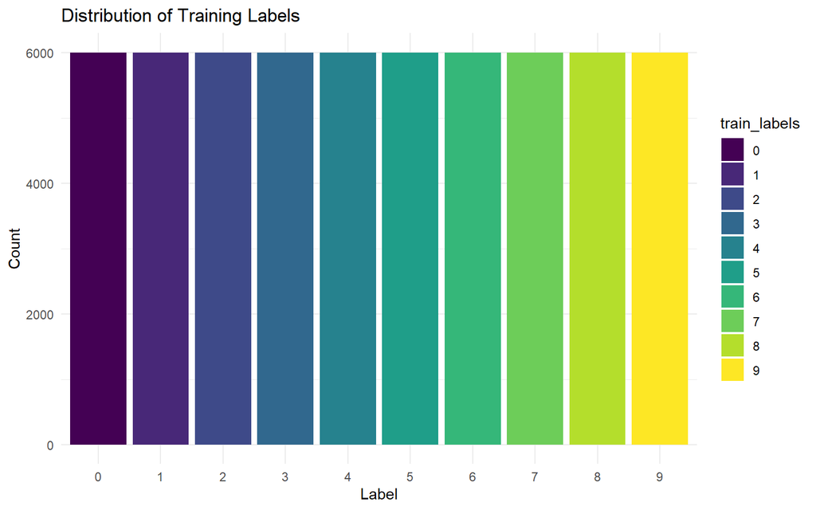

```r
# Create a bar plot
ggplot(as.data.frame(table(train_labels)), aes(x = train_labels, y = Freq, fill = train_labels)) +
  geom_bar(stat = "identity") + # Use geom_bar to create a bar plot
  theme_minimal() + # Apply a minimal theme
  labs(title = "Distribution of Training Labels",
       x = "Label",
       y = "Count") +
  scale_fill_viridis_d() # Use a viridis color scale for the fill
```

Let’s check the same thing for our test set. What are the dimensions?

```r
dim(test_images)
```

```
## [1] 10000    28    28
```

There are 10,000 images in the test set. Again, each image is represented as 28 x 28 pixels:

And the test set contains 10,000 images labels.

```r
dim(test_labels)
```

```
## [1] 10000
```

## Preprocess the data

Before training the neural network, the data must be preprocessed. Let’s inspect the first image in the training set: You will see that the pixel values fall in the range of 0 to 255:

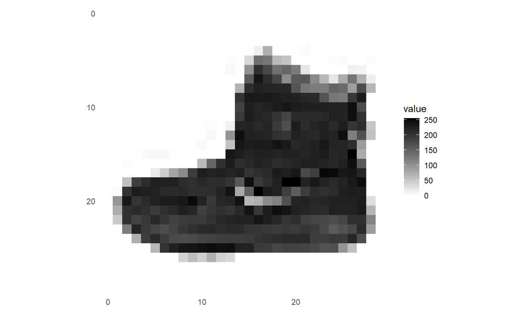

```r
# Convert the first image in 'train_images' to a dataframe.
image_1 <- as.data.frame(train_images[1, , ])

# Assign sequential column names based on pixel column position.
colnames(image_1) <- seq_len(ncol(image_1))

# Add a 'y' column to indicate the row position of each pixel.
image_1$y <- seq_len(nrow(image_1))

# Reshape dataframe to long format, gathering pixel values into 'x' and 'value' columns.
image_1 <- gather(image_1, "x", "value", -y)

# Convert 'x' column values to integers for correct axis representation.
image_1$x <- as.integer(image_1$x)

# Plot the first image of the training dataframe
ggplot(image_1, aes(x = x, y = y, fill = value)) +
  geom_tile() +
  scale_fill_gradient(low = "white", high = "black", na.value = NA) +
  scale_y_reverse() +
  theme_minimal() +
  theme(panel.grid = element_blank())   +
  theme(aspect.ratio = 1) +
  xlab("") +
  ylab("")
```

This seems to be a shoe. But let’s double check in our training labels.

```r
train_labels[1]
```

```
## [1] 9
```

We scale these values to a range of 0 to 1 before feeding to the neural network model. For this, we simply divide by 255.

It’s important that the training set and the testing set are preprocessed in the same way:

```r
train_images <- train_images / 255
test_images <- test_images / 255
```

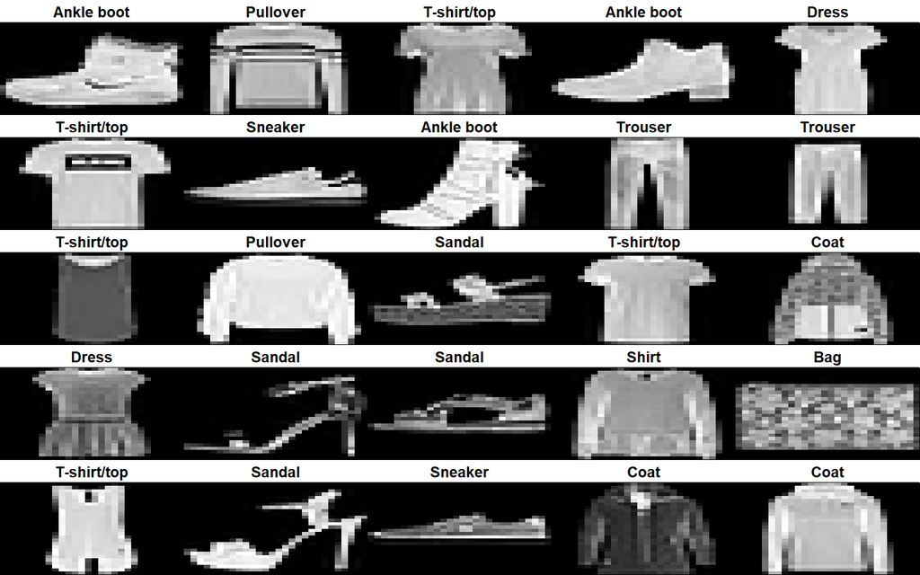

```r
# Set up plotting area for a 5x5 grid of images.
par(mfcol=c(5,5))

# Adjust margins and axis scaling for images.
par(mar=c(0, 0, 1.5, 0), xaxs='i', yaxs='i')

# Loop through the first 25 images to display them.
for (i in 1:25) {
  # Extract the i-th image, and rotate it for proper orientation.
  img <- train_images[i, , ]
  img <- t(apply(img, 2, rev))

  # Display the image with grayscale coloring and remove axis ticks, adding a label from class_names.
  image(1:28, 1:28, img, col = gray((0:255)/255), xaxt = 'n', yaxt = 'n',
        main = paste(class_names[train_labels[i] + 1]))
}
```

## Build the model

Building the neural network requires configuring the layers of the model, then compiling the model.

### Setup the layers

The basic building block of a neural network is the layer. Layers extract representations from the data fed into them. And, hopefully, these representations are more meaningful for the problem at hand.

Most of deep learning consists of chaining together simple layers. Most layers, like `layer_dense`, have parameters that are learned during training.

```r
model <- keras_model_sequential()
model %>%
  layer_flatten(input_shape = c(28, 28)) %>%
  layer_dense(units = 128, activation = 'relu') %>%
  layer_dense(units = 10, activation = 'softmax')
```

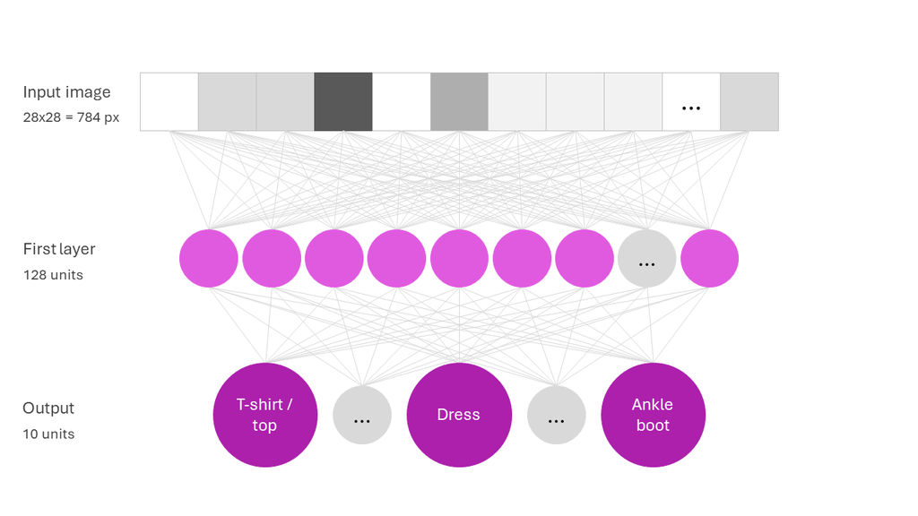

Visualisation of the model

The first layer in this network, `layer_flatten`, transforms the format of the images from a 2d-array (of 28 by 28 pixels), to a 1d-array of 28 * 28 = 784 pixels. Think of this layer as unstacking rows of pixels in the image and lining them up. This layer has no parameters to learn; it only reformats the data.

After the pixels are flattened, the network consists of a sequence of two `dense` layers. These are densely-connected, or fully-connected, neural layers. The first dense layer has 128 nodes (or neurons). The second (and last) layer is a 10-node softmax layer —this returns an array of 10 probability scores that sum to 1. Each node contains a score that indicates the probability that the current image belongs to one of the 10 digit classes.

### Compile the model

Before the model is ready for training, it needs a few more settings. These are added during the model’s compile step:

- Loss function — This measures how accurate the model is during training. We want to minimize this function to “steer” the model in the right direction.
- Optimizer — This is how the model is updated based on the data it sees and its loss function.
- Metrics —Used to monitor the training and testing steps. The following example uses accuracy, the fraction of the images that are correctly classified.

```r
model %>% compile(
  optimizer = 'adam',
  loss = 'sparse_categorical_crossentropy',
  metrics = c('accuracy')
)
```

```r
summary(object = model)
```

```
## Model: "sequential"
## ________________________________________________________________________________
## Layer (type)                        Output Shape                    Param #
## ================================================================================
## flatten (Flatten)                   (None, 784)                     0
## ________________________________________________________________________________
## dense_1 (Dense)                     (None, 128)                     100480
## ________________________________________________________________________________
## dense (Dense)                       (None, 10)                      1290
## ================================================================================
## Total params: 101,770
## Trainable params: 101,770
## Non-trainable params: 0
## ________________________________________________________________________________
```

### Train the model

Training the neural network model requires the following steps:

- Feed the training data to the model — in this example, the `train_images` and `train_labels` arrays.
- The model learns to associate images and labels.
- We ask the model to make predictions about a test set — in this example, the test_images array. We verify that the predictions match the labels from the test_labels array.

To start training, call the `fit` method — the model is “fit” to the training data:

```r
model %>% fit(train_images, train_labels, epochs = 5, verbose = 2)
```

```
## 1875/1875 - 2s - loss: 0.5051 - accuracy: 0.8207
## 1875/1875 - 2s - loss: 0.3817 - accuracy: 0.8624
## 1875/1875 - 2s - loss: 0.3444 - accuracy: 0.8747
## 1875/1875 - 2s - loss: 0.3177 - accuracy: 0.8836
## 1875/1875 - 2s - loss: 0.3000 - accuracy: 0.8890
```

As the model trains, the loss and accuracy metrics are displayed. This model reaches an accuracy of about 0.88 (or 88%) on the training data.

### Evaluate accuracy

Next, compare how the model performs on the test dataset:

```r
score <- model %>% evaluate(test_images, test_labels, verbose = 0)

cat('Test loss:', score["loss"], "\n")
```

```
## Test loss: 0.3664077
```

```r
cat('Test accuracy:', score["accuracy"], "\n")
```

```
## Test accuracy: 0.8663
```

It turns out, the accuracy on the test dataset is a little less than the accuracy on the training dataset. This gap between training accuracy and test accuracy is an example of overfitting. Overfitting is when a machine learning model performs worse on new data than on their training data.

### Make predictions

With the model trained, we can use it to make predictions about some images.

```r
predictions <- model %>% predict(test_images)
```

Here, the model has predicted the label for each image in the testing set. Let’s take a look at the first prediction:

```r
predictions[1, ]
```

```
##  [1] 1.415117e-04 1.660686e-05 2.381878e-05 2.140197e-06 3.011160e-05
##  [6] 8.551529e-02 4.282412e-05 1.094849e-02 4.291924e-04 9.028499e-01
```

A prediction is an array of 10 numbers. These describe the “confidence” of the model that the image corresponds to each of the 10 different articles of clothing. We can see which label has the highest confidence value:

```r
which.max(predictions[1, ])
```

```
## [1] 10
```

```r
test_labels[1]
```

```
## [1] 9
```

Let’s plot several images with their predictions. Correct prediction labels are green and incorrect prediction labels are red.

[figure not shown]

```r
par(mfcol=c(5,5))
par(mar=c(0, 0, 1.5, 0), xaxs='i', yaxs='i')
for (i in 1:25) {
  img <- test_images[i, , ]
  img <- t(apply(img, 2, rev))
  # subtract 1 as labels go from 0 to 9
  predicted_label <- which.max(predictions[i, ]) - 1
  true_label <- test_labels[i]
  if (predicted_label == true_label) {
    color <- '#008800'
  } else {
    color <- '#bb0000'
  }
  image(1:28, 1:28, img, col = gray((0:255)/255), xaxt = 'n', yaxt = 'n',
        main = paste0(class_names[predicted_label + 1], " (",
                      class_names[true_label + 1], ")"),
        col.main = color)
}
```

```r
# Convert softmax output to predicted labels
predicted_labels <- apply(predictions, 1, which.max) - 1 # subtract 1 to align with 0-based indexing of labels

# Actual labels are already in 'test_labels'

# Use the table function to create a confusion matrix
confusion_matrix <- table(Predicted = predicted_labels, Actual = test_labels)

# Print the confusion matrix
print(confusion_matrix)
```

```
##          Actual
## Predicted   0   1   2   3   4   5   6   7   8   9
##         0 801   0  11  10   0   0 132   0   3   0
##         1   8 973   4  12   2   0   6   0   0   0
##         2  42   0 846  19 169   0 124   0   6   0
##         3  60  21  15 915  36   0  60   0   5   0
##         4   7   2  65  27 706   0  47   0   5   0
##         5   2   0   0   0   0 970   0  40   4  26
##         6  66   1  54  13  83   0 614   0   2   1
##         7   0   0   0   0   0  18   0 910   2  18
##         8  14   3   5   4   4   2  17   1 973   0
##         9   0   0   0   0   0  10   0  49   0 955
```

Now you know how to use basic computer vision methods in R!

[^1]: This session builds on materials by TensorFlow and RStudio.